# 德国爱他美奶粉市场调查报告

何征

2015年7月2日

## 数据来源

以“德国爱他美”为关键字在taobao.com搜索，在售SKU每页显示44个，搜索结果超过100页。按销量排序，下载前100页德国爱他美销售数据。数据采集时间为2015年7月1日，共提取了4400个SKU的价格及销售情况。为便于比较，从4400个SKU中又选取了3577个有每500g价格的SKU。

数据提取第一页网址：

http://s.taobao.com/search?q=%E5%BE%B7%E5%9B%BD%E7%88%B1%E4%BB%96%E7%BE%8E&commend=all&ssid=s5-e&search_type=item&sourceId=tb.index&spm=a21bo.7724922.8452-taobao-item.2&initiative_id=tbindexz_&cps=yes&ppath=21299%3A27413&sort=sale-desc&bcoffset=0&s=0

## 基本统计数据

最高价(每500g)：1425 最低价(每500g)：17.19 平均价(每500g)：147.52 中间价(每500g)：144.5

最高销量：923 最低销量：4 平均销量：15.14 中间销量：7 总销量：54143

最高营业额：141588 最低营业额：100 平均营业额：2867.77 中间营业额：1320 总营业额：10258027.63

用销量前8位的店铺的销量占全部销量的百分比计算出市场集中度为：9.19%

## 价格与销量的关系

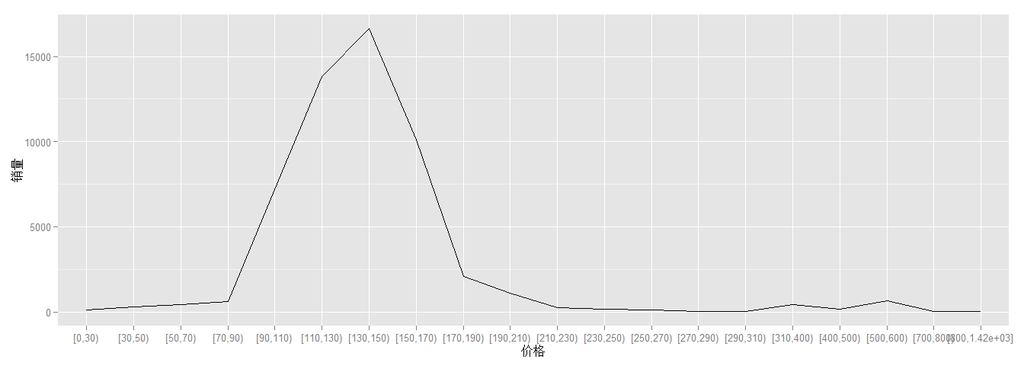

## 价格与营业额的关系

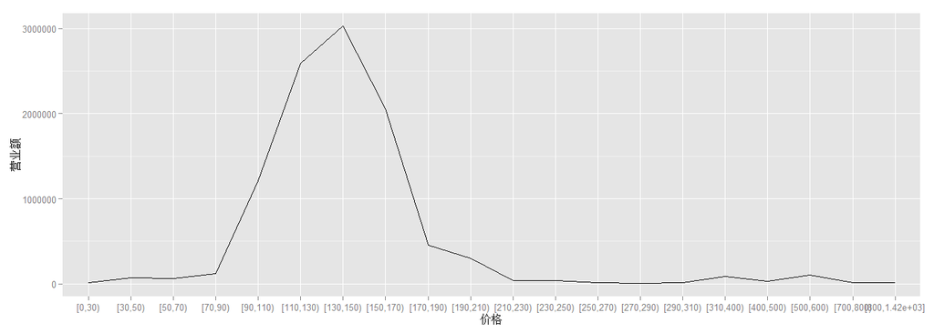

## 结论

130元至150元/500g是这款奶粉最畅销的价格区间。销售价格可以订在110元至170元/500g之间，利润水平也可以根据这个价格区间计算。